# Cellular assays using ‘bioassays’ package in R

Anwar Azad Palakkan, Jamie Davies

```r
library(bioassays)
```

# Libraries

Following libraries will be useful. If the libraries are not installed, please install them using **install.packages()**

```r
library(tcltk)# for selecting the folder for analysis
library(dplyr)
library(ggplot2)# for plotting graphs
library(reshape2)
library(nplr)# for the standard curve fitting
```

# Introduction

In a cell culture lab various cellular assays are performed. The package “bioassays” will help to analyse the results of these experiments performed in multiwell plates. The functions in this package can be used to summarise data from any multiwell plate, and by incorporating them in a loop several plates can be analyzed automatically. Two examples are shown in this article. All the csv files used for the examples are availble in the folder exdata (inst/exdata).

# Example 1: Analysing result from a 96 well plate

## Input data

To set up a folder as working directory

```r
path1<-tk_choose.dir(getwd(), "Choose the folder for Analysis")
# A window will popup and ask you to select the folder containg the data
setwd(path1)
```

Read files

Files can be read using the codes below. Files need to be in .csv format. In this examples file names reflect the type of assay used. For example *“L_DIFF_P3_72HRS.csv”* :*L* is assay code (Lactate assay), *DIFF* differentiation (type of cells used), *p3*: Plate 3 (each plate represent specific compounds tested), *72HRS* 72hrs treatment with compound. These information will help to summarise the results.

```r
filelist <-list("L_HEPG2_P3_72HRS.csv","L_HEPG2_P3_24HRS.csv") # list of files
fno<-1 # file number (in fileslist) that is going to be analyzed
result <- data.frame(stringsAsFactors= FALSE) ## An empty dataframe to dump result
zzz <- data.frame(stringsAsFactors= FALSE) ## An empty dataframe to dump result
```

To read 1st file

```r
filename<-extract_filename(filelist[fno])[1]
filename
```

```
#> [1] "L_HEPG2_P3_72HRS.csv"
```

```r
nickname<-extract_filename(filelist[fno], split="_",end=".csv",remove="",sep="")[2]
nickname
```

```
#> [1] "LHEPG2P372HRS"
```

```r
rawdata<-read.csv(filename,stringsAsFactors = FALSE, strip.white = TRUE,
                  na.strings = c("NA",""),header = TRUE,skip=1)
head(rawdata)
```

```
#>   X    X1    X2    X3    X4    X5    X6    X7    X8    X9   X10   X11   X12
#> 1 A 0.659 0.649 0.598 0.601 0.541 0.553 0.568 0.519 0.576 0.575 0.583 0.504
#> 2 B 0.442 0.455 0.586 0.563 0.525 0.548 0.511 0.503 0.533 0.559 0.529 0.535
#> 3 C 0.278 0.266 0.491 0.562 0.510 0.473 0.467 0.433 0.382 0.457 0.475 0.510
#> 4 D 0.197 0.199 0.452 0.456 0.421 0.431 0.409 0.401 0.458 0.412 0.408 0.403
#> 5 E 0.177 0.174 0.447 0.437 0.392 0.412 0.368 0.396 0.397 0.358 0.360 0.393
#> 6 F 0.141 0.137 0.277 0.337 0.294 0.279 0.257 0.263 0.262 0.292 0.280 0.300
```

Reading metadata file

```r
metadata<-read.csv("metafile.csv",stringsAsFactors = FALSE,strip.white = TRUE,
                  na.strings = c("NA",""),header = TRUE)
head(metadata)
```

```
#>   row col position type     id concentration dilution
#> 1   A   1      A01 STD1    STD            25       NA
#> 2   A   2      A02 STD1    STD            25       NA
#> 3   A   3      A03   S1 Sample            NA       NA
#> 4   A   4      A04   S1 Sample            NA       NA
#> 5   A   5      A05   S1 Sample            NA       NA
#> 6   A   6      A06   S1 Sample            NA       NA
```

## Rearranging the data

```r
rawdata<-data2plateformat(rawdata,platetype = 96)
head(rawdata)
```

```
#>       1     2     3     4     5     6     7     8     9    10    11    12
#> A 0.659 0.649 0.598 0.601 0.541 0.553 0.568 0.519 0.576 0.575 0.583 0.504
#> B 0.442 0.455 0.586 0.563 0.525 0.548 0.511 0.503 0.533 0.559 0.529 0.535
#> C 0.278 0.266 0.491 0.562 0.510 0.473 0.467 0.433 0.382 0.457 0.475 0.510
#> D 0.197 0.199 0.452 0.456 0.421 0.431 0.409 0.401 0.458 0.412 0.408 0.403
#> E 0.177 0.174 0.447 0.437 0.392 0.412 0.368 0.396 0.397 0.358 0.360 0.393
#> F 0.141 0.137 0.277 0.337 0.294 0.279 0.257 0.263 0.262 0.292 0.280 0.300
```

## To convert data into a dataframe.

```r
OD_df<- plate2df(rawdata)
head(OD_df)
```

```
#>   row col position value
#> 1   A   1      A01 0.659
#> 2   A   2      A02 0.649
#> 3   A   3      A03 0.598
#> 4   A   4      A04 0.601
#> 5   A   5      A05 0.541
#> 6   A   6      A06 0.553
```

## For an overview of the plate

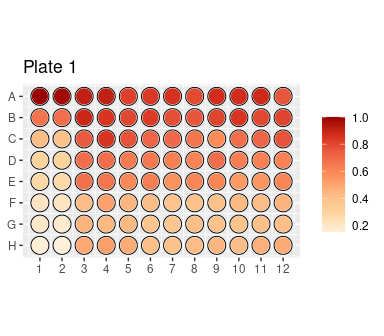

```r
data<-matrix96(OD_df,"value",rm="TRUE")
heatplate(data,"Plate 1", size=5)
```

## Filling metadata file using plate specific details

An example function is given below which will determine the compound,concentration, type and dilution from the file name

```r
plate_info<-function(file,i){

  file<-file[1]
  plate<- extract_filename(file,split = "_",end = ".csv", remove = " ", sep=" ")[5]

if(plate == "P2"){
  compound<-"CyclosporinA"   # Concentration of cyclosporinA used for experiment
  concentration<-c(0,1,5,10,15,20,25,50) # Concentration of cyclosporinA used for experiment
  type<-c("S1","S2","S3","S4","S5","S6","S7","S8") # sample names of corresponding concentration
  dilution<-5
  plate_meta<-list(compound=compound,concentration=round(concentration,2),type=type,
                   dilution=dilution)
}


if(plate == "P3"){
  compound<-"Taxol"
  concentration<-c(0,0.0125,.025,.05,0.1,1,5,10)
  type<-c("S1","S2","S3","S4","S5","S6","S7","S8")
  dilution<-5
  plate_meta<-list(compound=compound,concentration=round(concentration,2),type=type,
                   dilution=dilution)
}


if(plate =="p4"){
  compound<-c("Cisplatin")
  concentration<-c(0,0.5,2,4,8,16,64,"")
  type<-c("S1","S2","S3","S4","S5","S6","S7","")
  dilution <- 5
  plate_meta<-list(compound=compound,concentration=round(concentration,2),type=type,
                   dilution=dilution)
}
  return(plate_meta)
}

plate_details<-plate_info(filelist,1)
plate_details
```

```
#> $compound
#> [1] "Taxol"
#>
#> $concentration
#> [1]  0.00  0.01  0.03  0.05  0.10  1.00  5.00 10.00
#>
#> $type
#> [1] "S1" "S2" "S3" "S4" "S5" "S6" "S7" "S8"
#>
#> $dilution
#> [1] 5
```

These ‘plate details’ can be used to fill metadata using plate_metadata function

```r
metadata1<-plate_metadata(plate_details,metadata,mergeby="type")
head(metadata1)
```

```
#>   row col type position     id dilution concentration compound
#> 1   A   1 STD1      A01    STD       NA            25     <NA>
#> 2   A   2 STD1      A02    STD       NA            25     <NA>
#> 3   A   3   S1      A03 Sample        5             0    Taxol
#> 4   A   4   S1      A04 Sample        5             0    Taxol
#> 5   A   5   S1      A05 Sample        5             0    Taxol
#> 6   A   6   S1      A06 Sample        5             0    Taxol
```

For joining metadata and platelayout ‘inner_join’ function is used

```r
data_DF<- dplyr::inner_join(OD_df,metadata1,by=c("row","col","position"))
assign(paste("data",sep="_",nickname),data_DF) # create a copy of data with platename
head(data_DF)
```

```
#>   row col position value type     id dilution concentration compound
#> 1   A   1      A01 0.659 STD1    STD       NA            25     <NA>
#> 2   A   2      A02 0.649 STD1    STD       NA            25     <NA>
#> 3   A   3      A03 0.598   S1 Sample        5             0    Taxol
#> 4   A   4      A04 0.601   S1 Sample        5             0    Taxol
#> 5   A   5      A05 0.541   S1 Sample        5             0    Taxol
#> 6   A   6      A06 0.553   S1 Sample        5             0    Taxol
```

## Sorting blank wells and reducing blanks

Blank can be reduced using ‘reduceblank’ function

```r
data_DF<-reduceblank(data_DF, x_vector =c("All"),blank_vector = c("Blank"), "value")
head(data_DF)
```

```
#>   row col position value type     id dilution concentration compound blankminus
#> 1   A   1      A01 0.659 STD1    STD       NA            25     <NA>     0.5545
#> 2   A   2      A02 0.649 STD1    STD       NA            25     <NA>     0.5445
#> 3   A   3      A03 0.598   S1 Sample        5             0    Taxol     0.4935
#> 4   A   4      A04 0.601   S1 Sample        5             0    Taxol     0.4965
#> 5   A   5      A05 0.541   S1 Sample        5             0    Taxol     0.4365
#> 6   A   6      A06 0.553   S1 Sample        5             0    Taxol     0.4485
```

```r
assign(paste("Blkmin",sep="_",nickname),data_DF) # create a copy of data with platename
```

## Plotting standard curve

To filter standards

```r
std<- dplyr::filter(data_DF, data_DF$id=="STD")
std<- aggregate(std$blankminus ~ std$concentration, FUN = mean )
colnames (std) <-c("con", "OD")
head(std)
```

```
#>     con     OD
#> 1  0.39 0.0155
#> 2  0.78 0.0345
#> 3  1.56 0.0710
#> 4  3.13 0.0935
#> 5  6.25 0.1675
#> 6 12.50 0.3440
```

Calculations for standard curve : nonparametric logistic regression curve

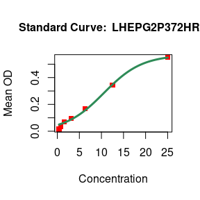

```r
fit1<-nplr::nplr(std$con,std$OD,npars=3,useLog = FALSE)
#npars = 3 for 3 parametric regression curve

#for graph
x1 <- nplr::getX(fit1); y1 <- nplr::getY(fit1)
x2 <- nplr::getXcurve(fit1); y2 <- nplr::getYcurve(fit1)
plot(x1, y1, pch=15, cex=1, col="red", xlab="Concentration",
     ylab="Mean OD", main=paste("Standard Curve: ", nickname), cex.main=1)
lines(x2, y2, lwd=3, col="seagreen4")
```

To evaluate nonparametric logistic regression fitting

```r
params<-nplr::getPar(fit1)$params
nplr::getGoodness(fit1)
```

```
#> $gof
#> [1] 0.9919475
#>
#> $wgof
#> [1] 0.9995859
```

To estimate the values based on logistic regression fitting

```r
estimated_nplr<-estimate(data_DF,colname="blankminus",fitformula=fit1,method="nplr")
```

```
#> These values have been replaced by the minimal possible value the model can estimate.
```

```r
head(estimated_nplr)
```

```
#>   row col position value type     id dilution concentration compound blankminus
#> 1   A   1      A01 0.659 STD1    STD       NA            25     <NA>     0.5545
#> 2   A   2      A02 0.649 STD1    STD       NA            25     <NA>     0.5445
#> 3   A   3      A03 0.598   S1 Sample        5             0    Taxol     0.4935
#> 4   A   4      A04 0.601   S1 Sample        5             0    Taxol     0.4965
#> 5   A   5      A05 0.541   S1 Sample        5             0    Taxol     0.4365
#> 6   A   6      A06 0.553   S1 Sample        5             0    Taxol     0.4485
#>   estimated
#> 1  26.39687
#> 2  24.01751
#> 3  18.68524
#> 4  18.88785
#> 5  15.70869
#> 6  16.23867
```

Calculations for standard curve : linear regression curve

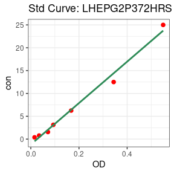

```r
fit2<-stats::lm(formula = con ~ OD,data = std)
ggplot2::ggplot(std, ggplot2::aes(x=OD,y=con))+
ggplot2::ggtitle(paste("Std Curve:", nickname))+
ggplot2::geom_point(color="red",size=2)+
ggplot2::geom_line(data = ggplot2::fortify(fit2),ggplot2::aes(x=OD,y=.fitted),
          colour="seagreen4",size=1)+
ggplot2::theme_bw()
```

To evaluate linear fitting

```r
conpred<-estimate(std,colname="OD",fitformula=fit2,method="linear")
compare<-conpred[,c(1,3)]
corAccuracy<-cor(compare)[1,2]
corAccuracy ## Correlation accuracy of regression line
```

```
#> [1] 0.9932859
```

```r
summary(fit2)
```

```
#>
#> Call:
#> stats::lm(formula = con ~ OD, data = std)
#>
#> Residuals:
#>        1        2        3        4        5        6        7
#>  0.86249  0.39094 -0.48415  0.06559 -0.16993 -1.92329  1.25834
#>
#> Coefficients:
#>             Estimate Std. Error t value Pr(>|t|)
#> (Intercept)  -1.1753     0.6078  -1.934    0.111
#> OD           45.3448     2.3618  19.199 7.07e-06 ***
#> ---
#> Signif. codes:  0 '***' 0.001 '**' 0.01 '*' 0.05 '.' 0.1 ' ' 1
#>
#> Residual standard error: 1.135 on 5 degrees of freedom
#> Multiple R-squared:  0.9866, Adjusted R-squared:  0.9839
#> F-statistic: 368.6 on 1 and 5 DF,  p-value: 7.069e-06
```

To estimate the values based on linear curve

```r
estimated_lr<-estimate(data_DF,colname="blankminus",fitformula=fit2,method="linear")
head(estimated_lr)
```

```
#>   row col position value type     id dilution concentration compound blankminus
#> 1   A   1      A01 0.659 STD1    STD       NA            25     <NA>     0.5545
#> 2   A   2      A02 0.649 STD1    STD       NA            25     <NA>     0.5445
#> 3   A   3      A03 0.598   S1 Sample        5             0    Taxol     0.4935
#> 4   A   4      A04 0.601   S1 Sample        5             0    Taxol     0.4965
#> 5   A   5      A05 0.541   S1 Sample        5             0    Taxol     0.4365
#> 6   A   6      A06 0.553   S1 Sample        5             0    Taxol     0.4485
#>   estimated
#> 1  23.96838
#> 2  23.51493
#> 3  21.20234
#> 4  21.33838
#> 5  18.61769
#> 6  19.16183
```

For multiply estimated by dilution

```r
estimated_lr$estimated2 <- estimated_lr$estimated * estimated_lr$dilution
head(estimated_lr)
```

```
#>   row col position value type     id dilution concentration compound blankminus
#> 1   A   1      A01 0.659 STD1    STD       NA            25     <NA>     0.5545
#> 2   A   2      A02 0.649 STD1    STD       NA            25     <NA>     0.5445
#> 3   A   3      A03 0.598   S1 Sample        5             0    Taxol     0.4935
#> 4   A   4      A04 0.601   S1 Sample        5             0    Taxol     0.4965
#> 5   A   5      A05 0.541   S1 Sample        5             0    Taxol     0.4365
#> 6   A   6      A06 0.553   S1 Sample        5             0    Taxol     0.4485
#>   estimated estimated2
#> 1  23.96838         NA
#> 2  23.51493         NA
#> 3  21.20234  106.01172
#> 4  21.33838  106.69189
#> 5  18.61769   93.08844
#> 6  19.16183   95.80913
```

## Summarise the data

For summarising the “estimated_lr” based on “id” and “type”.

```r
result<-dfsummary(estimated_lr,"estimated2",c("id","type"),
        c("STD","Blank"),"plate1", rm="FALSE",
        param=c(strict="FALSE",cutoff=40,n=12))
```

```
#> F1
#> F2
```

```r
result
```

```
#>       id type  label  N   Mean     SD    CV
#> 1 Sample   S1 plate1 10 97.804  7.325  7.49
#> 2 Sample   S2 plate1 10 92.680  5.703  6.15
#> 3 Sample   S3 plate1 10 78.351 10.970 14.00
#> 4 Sample   S4 plate1 10 66.811  5.128  7.68
#> 5 Sample   S5 plate1 10 60.213  6.797 11.29
#> 6 Sample   S6 plate1 10 34.843  5.329 15.30
#> 7 Sample   S7 plate1 10 31.850  4.094 12.85
#> 8 Sample   S8 plate1 10 38.062  5.869 15.42
```

## Statistical test

For the t test (S1 as control)

```r
pval<-pvalue(result, control="S1", sigval=0.05)
head(pval)
```

[output not shown]

# Example 2: Analysing result from a 384 well plate.

This example data contain result of dose response of few drugs (drug1, drug2, drug3, drug4) at three concentrations (C1,C2,C3) from two different cell lines (hepg2 and huh7)

## Input data.

Reading the spectrophotometer readings in csv file

```r
rawdata2<-read.csv("384.csv",stringsAsFactors = FALSE,strip.white = TRUE,
                  na.strings = c("NA",""),header = TRUE,skip=1)
dim(rawdata2)
head(rawdata2)
```

```
#> [1] 16 25
#>   X  X1  X2  X3  X4  X5  X6  X7  X8  X9 X10 X11 X12 X13 X14 X15 X16 X17 X18 X19
#> 1 A 0.1 0.1 0.2 0.3 0.2 0.2 0.2 0.2 0.2 0.2 0.2 0.1 0.2 0.3 0.4 0.5 0.6 0.5 0.6
#> 2 B 0.2 0.2 0.2 0.2 0.3 0.3 0.3 0.3 0.3 0.3 0.3 0.2 0.2 0.2 0.3 0.3 0.3 0.3 0.3
#> 3 C 0.3 0.3 0.3 0.3 0.4 0.4 0.4 0.4 0.4 0.4 0.4 0.3 0.3 0.3 0.4 0.4 0.4 0.4 0.4
#> 4 D 0.4 0.4 0.4 0.4 0.5 0.5 0.5 0.5 0.5 0.5 0.5 0.4 0.4 0.4 0.5 0.5 0.5 0.5 0.5
#> 5 E 0.5 0.5 0.5 0.5 0.6 0.6 0.6 0.6 0.6 0.6 0.6 0.5 0.5 0.5 0.6 0.6 0.6 0.6 0.6
#> 6 F 0.6 0.6 0.6 0.6 0.7 0.7 0.7 0.7 0.7 0.7 0.7 0.6 0.6 0.6 0.7 0.7 0.7 0.7 0.7
#>   X20 X21 X22 X23 X24
#> 1 0.7 0.8 0.9 1.0 0.1
#> 2 0.3 0.3 0.3 0.3 0.3
#> 3 0.4 0.4 0.4 0.4 0.4
#> 4 0.5 0.5 0.5 0.5 0.5
#> 5 0.2 0.2 0.3 0.3 0.2
#> 6 0.3 0.3 0.4 0.4 0.3
```

Reading metadata

```r
metadata2<-read.csv("metafile_384_plate.csv",stringsAsFactors = FALSE,strip.white = TRUE,
                   na.strings = c("NA",""),header = TRUE)
head(metadata2)
```

```
#>   row col position  cell compound concentration    type dilution
#> 1   A   1      A01 hepg2    drug1             B  blank1       NA
#> 2   A   2      A02 hepg2    drug1            C1 treated       10
#> 3   A   3      A03 hepg2    drug1            C1 treated       10
#> 4   A   4      A04 hepg2    drug1            C1 treated       10
#> 5   A   5      A05 hepg2    drug1            C1 treated       10
#> 6   A   6      A06 hepg2    drug1            C1 treated       10
```

## Rearranging the data.

For appropriate naming of rows and column of rawdata2

```r
rawdata2<-data2plateformat(rawdata2,platetype = 384)
head(rawdata2)
```

```
#>     1   2   3   4   5   6   7   8   9  10  11  12  13  14  15  16  17  18  19
#> A 0.1 0.1 0.2 0.3 0.2 0.2 0.2 0.2 0.2 0.2 0.2 0.1 0.2 0.3 0.4 0.5 0.6 0.5 0.6
#> B 0.2 0.2 0.2 0.2 0.3 0.3 0.3 0.3 0.3 0.3 0.3 0.2 0.2 0.2 0.3 0.3 0.3 0.3 0.3
#> C 0.3 0.3 0.3 0.3 0.4 0.4 0.4 0.4 0.4 0.4 0.4 0.3 0.3 0.3 0.4 0.4 0.4 0.4 0.4
#> D 0.4 0.4 0.4 0.4 0.5 0.5 0.5 0.5 0.5 0.5 0.5 0.4 0.4 0.4 0.5 0.5 0.5 0.5 0.5
#> E 0.5 0.5 0.5 0.5 0.6 0.6 0.6 0.6 0.6 0.6 0.6 0.5 0.5 0.5 0.6 0.6 0.6 0.6 0.6
#> F 0.6 0.6 0.6 0.6 0.7 0.7 0.7 0.7 0.7 0.7 0.7 0.6 0.6 0.6 0.7 0.7 0.7 0.7 0.7
#>    20  21  22  23  24
#> A 0.7 0.8 0.9 1.0 0.1
#> B 0.3 0.3 0.3 0.3 0.3
#> C 0.4 0.4 0.4 0.4 0.4
#> D 0.5 0.5 0.5 0.5 0.5
#> E 0.2 0.2 0.3 0.3 0.2
#> F 0.3 0.3 0.4 0.4 0.3
```

## To convert data into a dataframe.

```r
OD_df2 <- plate2df(rawdata2)
head(OD_df2)
```

```
#>   row col position value
#> 1   A   1      A01   0.1
#> 2   A   2      A02   0.1
#> 3   A   3      A03   0.2
#> 4   A   4      A04   0.3
#> 5   A   5      A05   0.2
#> 6   A   6      A06   0.2
```

## For an overview of the plate.

For heat map

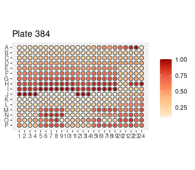

```r
data2<-matrix96(OD_df2,"value",rm="TRUE")
heatplate(data2,"Plate 384", size=1.5)
```

## For joining metadata2 and OD_df2.

```r
data_DF2<- dplyr::inner_join(OD_df2,metadata2,by=c("row","col","position"))
head(data_DF2)
```

```
#>   row col position value  cell compound concentration    type dilution
#> 1   A   1      A01   0.1 hepg2    drug1             B  blank1       NA
#> 2   A   2      A02   0.1 hepg2    drug1            C1 treated       10
#> 3   A   3      A03   0.2 hepg2    drug1            C1 treated       10
#> 4   A   4      A04   0.3 hepg2    drug1            C1 treated       10
#> 5   A   5      A05   0.2 hepg2    drug1            C1 treated       10
#> 6   A   6      A06   0.2 hepg2    drug1            C1 treated       10
```

For categorical view of cells

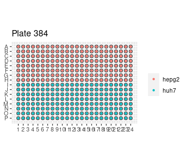

```r
data3<-matrix96(data_DF2,"cell",rm="TRUE")
heatplate(data3,"Plate 384", size=2)
```

For categorical view of compound

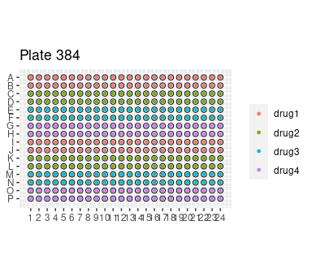

```r
data4<-matrix96(data_DF2,"compound",rm="TRUE")
heatplate(data4,"Plate 384", size=2)
```

## Sorting blank wells and reducing blanks.

The data contain separate blanks for drug1, drug2, drug3 and drug4 (blank1, blank2,blank3 and blank 4 respectively)

```r
data_blk<-reduceblank(data_DF2,
x_vector=c("drug1","drug2","drug3","drug4"),
blank_vector = c("blank1","blank2","blank3","blank4"), "value")
dim(data_blk)
```

```
#> [1] 384  10
```

```r
head(data_blk)
```

```
#>   row col position value  cell compound concentration    type dilution
#> 1   A   1      A01   0.1 hepg2    drug1             B  blank1       NA
#> 2   A   2      A02   0.1 hepg2    drug1            C1 treated       10
#> 3   A   3      A03   0.2 hepg2    drug1            C1 treated       10
#> 4   A   4      A04   0.3 hepg2    drug1            C1 treated       10
#> 5   A   5      A05   0.2 hepg2    drug1            C1 treated       10
#> 6   A   6      A06   0.2 hepg2    drug1            C1 treated       10
#>   blankminus
#> 1       -0.4
#> 2       -0.4
#> 3       -0.3
#> 4       -0.2
#> 5       -0.3
#> 6       -0.3
```

## To summarise the result from a plate.

For summarising the result in the order cell, compound,concentration,type and by omitting blanks.

```r
result2<-dfsummary(data_blk,"blankminus",
        c("cell","compound","concentration","type"),
        c("blank1","blank2","blank3","blank4"),
        nickname="384well",
        rm="FALSE",param=c(strict="FALSE",cutoff=40,n=12))
```

```
#> F1
#> F2
#> F3
#> F4
```

```r
head (result2)
```

```
#>    cell compound concentration      type   label N   Mean    SD     CV
#> 1 hepg2    drug1            C1   treated 384well 7 -0.300 0.058  19.25
#> 2 hepg2    drug1            C1 untreated 384well 8 -0.250 0.053  21.38
#> 3 hepg2    drug1            C2   treated 384well 8 -0.238 0.130  54.84
#> 4 hepg2    drug1            C2 untreated 384well 8 -0.238 0.052  21.79
#> 5 hepg2    drug1            C3   treated 384well 8  0.150 0.278 185.16
#> 6 hepg2    drug1            C3 untreated 384well 8 -0.200 0.000   0.00
```

```r
dim (result2)
```

```
#> [1] 48  9
```

For summarising the result in the order cell, compound and concentration and by omitting blanks (all blanks are marked as “B” in concentration), drug 2 and huh7.

```r
result3<-dfsummary(data_blk,"blankminus",
        c("cell","compound","concentration"),
        c("B","drug2","huh7"),
        nickname="",
        rm="FALSE",param=c(strict="FALSE",cutoff=40,n=12))
```

```
#> F1
#> F2
#> F3
```

```r
head (result3)
```

```
#>    cell compound concentration label  N   Mean    SD      CV
#> 1 hepg2    drug1            C1       15 -0.273 0.059   21.72
#> 2 hepg2    drug1            C2       16 -0.238 0.096   40.31
#> 3 hepg2    drug1            C3       16 -0.025 0.262 1048.17
#> 4 hepg2    drug3            C1       15  0.207 0.070   34.05
#> 5 hepg2    drug3            C2       16  0.212 0.072   33.83
#> 6 hepg2    drug3            C3       16  0.025 0.191  765.94
```

```r
dim (result3)
```

```
#> [1] 9 8
```

## Statistical test.

For t-test

```r
pvalue<-pvalue(result3,"C3",sigval=0.05)
pvalue
```

```
#>    cell compound concentration label  N   Mean    SD      CV   pvalue
#> 1 hepg2    drug1            C3       16 -0.025 0.262 1048.17 control
#> 2 hepg2    drug1            C1       15 -0.273 0.059   21.72  < 0.001
#> 3 hepg2    drug1            C2       16 -0.238 0.096   40.31   0.0024
#> 4 hepg2    drug3            C3       16  0.025 0.191  765.94 control
#> 5 hepg2    drug3            C1       15  0.207 0.070   34.05  < 0.001
#> 6 hepg2    drug3            C2       16  0.212 0.072   33.83  < 0.001
#> 7 hepg2    drug4            C3       16  0.063 0.266  424.83 control
#> 8 hepg2    drug4            C1       15  0.207 0.070   34.05   0.0258
#> 9 hepg2    drug4            C2       16  0.213 0.072   33.83   0.0187
#>   significance
#> 1
#> 2          Yes
#> 3          Yes
#> 4
#> 5          Yes
#> 6          Yes
#> 7
#> 8          Yes
#> 9          Yes
```